# Testing methods for determining carbonate in mangrove sediment samples of the U.S. Virgin Islands

A final project for GIS and Data Management Fall 2023

By: Julia Plotkin

Due: December 7th, 2023

## Background

When estimating sediment organic carbon carbon or sediment “blue carbon” in samples from carbonate regions such as the Caribbean, sources of inorganic carbonate must be accounted for.

### Acid Fumigation Technique

The acid fumigation technique first described by Heiri et al. 2001 has been widely accepted in mangrove blue carbon research to account for carbonate. This method involves wetting dry, homogenized sediment samples with de-ionized water and then fumigating these samples with pure (12M) HCl for a minimum of 6 hours in a desiccator jar. The carbonate dissolves out of the samples and leaves only organic carbon behind. This organic carbon can then be quantified directly using elemental analysis.

Although the recommended method for its low cost and simplicity, the acid fumigation technique has been critiqued for losing efficacy when samples contain particularly high concentrations of carbonate (>50%). Further, publications describing this technique have not included samples from mangrove sediments or other coastal blue carbon ecosystems such as seagrasses and salt marshes.

### Double Combustion

The alternative to acid fumigation is double combustion in which organic matter is first removed from the dry, homogenized sediment samples by combustion at a high temperature of 450C. Combusted samples, now only containing inorganic carbon, are then paired with uncombusted replicate samples containing both organic and inorganic components and analyzed by elemental analysis for carbon. The difference between carbon of the paired samples represents the target organic carbon content.

Although a more direct measure of inorganic carbon, double combustion of paired samples doubles the cost of the already expensive process of elemental analysis. Access to an elemental analyzer may also be a limiting factor of this technique.

## Purpose

Here, we compare the efficiency of these methods on a subset (n=43) of sediment samples from the first blue carbon assessment of mangroves in the U.S. Virgin Islands. These samples were selected to capture variability across sites, within sites, and between depth intervals of individual sediment cores.

## Data and Analysis

### Data

| site | type | tc.dc | ic.dc | oc.dc | oc.acid | difference |
| --- | --- | --- | --- | --- | --- | --- |
| CP | Salt Pond | 17.68 | 0.00 | 17.68 | 18.25 | 0.57 |
| CP | Salt Pond | 18.64 | 0.00 | 18.64 | 19.41 | 0.77 |
| CP | Salt Pond | 25.25 | 0.00 | 25.25 | 26.45 | 1.20 |
| CP | Salt Pond | 23.20 | 0.00 | 23.20 | 23.19 | -0.01 |
| GP | Salt Pond | 1.80 | 0.00 | 1.80 | 0.89 | -0.91 |
| GP | Salt Pond | 9.51 | 0.00 | 9.51 | 9.68 | 0.17 |
| GP | Salt Pond | 1.64 | 0.00 | 1.64 | 1.25 | -0.39 |
| KL | Fringe | 22.70 | 0.00 | 22.70 | 22.75 | 0.05 |
| PB | Salt Pond | 20.75 | 0.00 | 20.75 | 20.87 | 0.12 |
| PB | Salt Pond | 10.08 | 0.00 | 10.08 | 9.49 | -0.59 |
| PB | Salt Pond | 6.68 | 0.00 | 6.68 | 6.38 | -0.30 |
| PS | Salt Pond | 4.22 | 0.00 | 4.22 | 4.32 | 0.10 |
| PS | Salt Pond | 5.32 | 0.00 | 5.32 | 5.41 | 0.09 |
| STB | Basin | 13.36 | 0.00 | 13.36 | 13.28 | -0.08 |
| STB | Basin | 29.02 | 0.00 | 29.02 | 31.71 | 2.69 |
| STB | Basin | 26.93 | 0.00 | 26.93 | 28.84 | 1.91 |
| STB | Basin | 19.64 | 0.00 | 19.64 | 20.31 | 0.67 |
| STF | Fringe | 32.59 | 0.00 | 32.59 | 35.97 | 3.38 |
| STF | Fringe | 26.87 | 0.00 | 26.87 | 27.19 | 0.32 |
| STF | Fringe | 21.94 | 0.00 | 21.94 | 21.94 | 0.00 |
| STF | Fringe | 14.75 | 0.00 | 14.75 | 14.54 | -0.21 |
| CP | Salt Pond | 16.93 | 0.30 | 16.63 | 15.32 | -1.31 |
| SG | Salt Pond | 1.03 | 0.11 | 0.92 | 0.30 | -0.62 |
| SG | Salt Pond | 1.06 | 0.15 | 0.91 | 0.27 | -0.64 |
| KL | Fringe | 25.97 | 4.01 | 21.96 | 24.45 | 2.49 |
| VB | Fringe | 20.76 | 4.42 | 16.34 | 18.44 | 2.10 |
| VB | Fringe | 15.76 | 4.31 | 11.45 | 12.42 | 0.97 |
| VB | Fringe | 16.24 | 4.47 | 11.77 | 12.82 | 1.05 |
| MAG | Basin | 24.80 | 7.33 | 17.47 | 21.62 | 4.15 |
| BB | Fringe | 8.52 | 3.54 | 4.98 | 4.59 | -0.39 |
| PB | Salt Pond | 5.80 | 2.76 | 3.04 | 2.31 | -0.73 |
| STB | Basin | 8.79 | 4.32 | 4.47 | 3.74 | -0.73 |
| KL | Fringe | 17.90 | 9.58 | 8.32 | 14.85 | 6.53 |
| MB | Fringe | 9.81 | 6.04 | 3.77 | 6.63 | 2.86 |
| VB | Fringe | 6.63 | 4.18 | 2.45 | 2.47 | 0.02 |
| KL | Fringe | 12.43 | 8.33 | 4.10 | 6.70 | 2.60 |
| BB | Fringe | 6.60 | 4.67 | 1.93 | 1.40 | -0.53 |
| KL | Fringe | 12.80 | 9.73 | 3.07 | 8.73 | 5.66 |
| MAG | Basin | 12.66 | 10.09 | 2.57 | 4.98 | 2.41 |
| MB | Fringe | 11.38 | 9.07 | 2.31 | 2.46 | 0.15 |
| MAG | Basin | 11.57 | 9.66 | 1.91 | 6.49 | 4.58 |
| MAG | Basin | 11.03 | 10.03 | 1.00 | 4.78 | 3.78 |
| SR | Fringe | 11.71 | 11.33 | 0.38 | 6.15 | 5.77 |

### Statistics

Before running our paired statistical test, we assess the data for normality with a histogram and shapiro test:

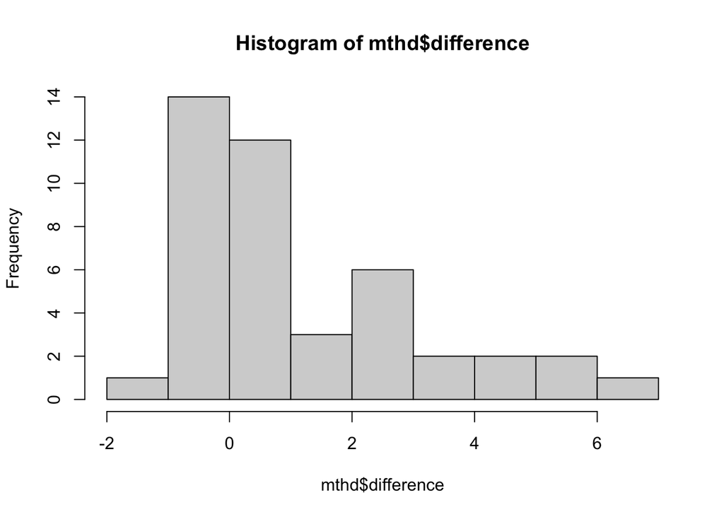

```r
hist(mthd$difference)
```

```r
shapiro.test(mthd$difference)
```

```
##
##  Shapiro-Wilk normality test
##
## data:  mthd$difference
## W = 0.86238, p-value = 0.0001087
```

Because our spread of difference data between the two carbonate determination methods is NOT normal, we use a non parametric paired t test, the wilcox test, to assess differences in our methods:

```r
print(wilcox.test(mthd$oc.acid, mthd$oc.dc, paired = TRUE))
```

```
##
##  Wilcoxon signed rank test with continuity correction
##
## data:  mthd$oc.acid and mthd$oc.dc
## V = 686, p-value = 0.003435
## alternative hypothesis: true location shift is not equal to 0
```

The results of our wilcox test is significant, suggesting the difference in organic carbon estimations between our two methods used to account for carbonate are significantly different.

### Plot

Here, we can visualize this difference where acid fumigation tends to overestimate organic carbon compared to the double combustion.

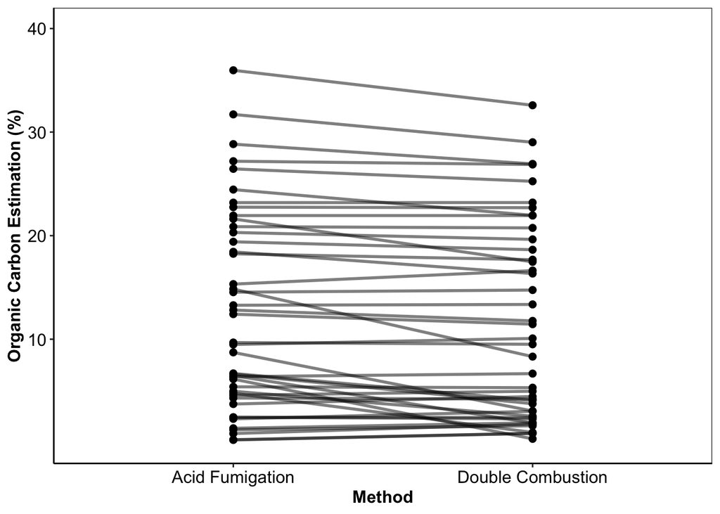

## Results and Discussion

These preliminary results suggest that there are significant differences in organic carbon estimations as a result of using acid fumigation or double combustion to account for inorganic carbon. While both methods have their statistical caveats and potential for error, double combustion is considered the more accurate and direct measurement for carbonate, and this study suggests acid fumigation may cause underestimation of carbonate in samples. This work will continue to assess this difference understand if inaccuracies from acid fumigation are more common in high carbonate samples and the technique may still be reliable for low carbonate samples.

Nevertheless, the results of this methods testing certainly has implications for researchers assessing organic sediments in carbonate regions such as the Caribbean.